[figure not shown]

# Introduction

There's no denying the importance of honey bees as they are responsible for one-third of all crop production in the United States. Making sure crops such as melons, apples, cranberries, squash, pumpkins, broccoli, and almonds stay stocked in grocery stores. However in recent years the population of honey bees have rapidly decreasing, in 2012 there was an peak of 3.28 million colonies and today there are 2.88 million colonies. This decline is linked to multiple factors including climate change, pests, pesticides, and diseases.

For this project, I'll be examining datasets retrieved from https://www.kaggle.com/datasets/kyleahmurphy/nass-honey-bee-20152021, containing charts on bee colonies, bee stressors, and bee honey. The data was retrieved from reports within the beekeeping industry includes hobbyists, part-timers, and commercial beekeepers. According to agmrc.org:

> "Hobby-sized operations are those with 25 colonies or less, hobbyists with less than 5 colonies are not included in the colonies reported by the USDA. Part-timers are those with 25 to 300 colonies, and commercial operations are those with over 300 colonies. Hobbyists and part-timers account for roughly 40 percent of the honey production, and 1,600 commercial beekeepers are responsible for the remaining 60 percent of production."

This project aims to examine the leading stressors that lead to bee colony losses in different regions in the U.S.

# Data Extraction

The libraries are imported to help format and plot the data. To get an idea of what information might be avaliable in discovering the goal of this project, I chose to examine the bee colony dataset first.

```python
import pandas as pd
import matplotlib.pyplot as plt
import datetime
from matplotlib.pyplot import figure
from matplotlib.dates import YearLocator, MonthLocator, DateFormatter
import seaborn as sns
import numpy as np

# Read in datasets
bee_col = pd.read_csv("NASS_Bee-Colony_2015-2021.csv")
bee_hon = pd.read_csv("NASS_Bee-Honey_2015-2021.csv")
bee_stress = pd.read_csv("NASS_Bee-Stressors_2015-2021.csv")

# Noticed the year column is based in quarters, convert rest of datasets to
# use datetime format
bee_col['Date'] = pd.to_datetime(bee_col.Year)
bee_stress['Date'] = pd.to_datetime(bee_stress.Year)

# Examine bee colony dataset
bee_col
```

|  | State | Starting Colonies | Maximum Colonies | Lost Colonies | Percent Loss | Added Colonies | Renovated Colonies | Percent Renovated | Year | Date |
| --- | --- | --- | --- | --- | --- | --- | --- | --- | --- | --- |
| 0 | Alabama | 7000 | 7000 | 1800 | 26 | 2800 | 250 | 4 | 2015-Q1 | 2015-01-01 |
| 1 | Arizona | 35000 | 35000 | 4600 | 13 | 3400 | 2100 | 6 | 2015-Q1 | 2015-01-01 |
| 2 | Arkansas | 13000 | 14000 | 1500 | 11 | 1200 | 90 | 1 | 2015-Q1 | 2015-01-01 |
| 3 | California | 1440000 | 1690000 | 255000 | 15 | 250000 | 124000 | 7 | 2015-Q1 | 2015-01-01 |
| 4 | Colorado | 3500 | 12500 | 1500 | 12 | 200 | 140 | 1 | 2015-Q1 | 2015-01-01 |
| ... | ... | ... | ... | ... | ... | ... | ... | ... | ... | ... |
| 1217 | West Virginia | 8000 | 9000 | 170 | 2 | 1900 | 390 | 4 | 2021-Q2 | 2021-04-01 |
| 1218 | Wisconsin | 42000 | 57000 | 2200 | 4 | 9000 | 7500 | 13 | 2021-Q2 | 2021-04-01 |
| 1219 | Wyoming | 13500 | 30000 | 3400 | 11 | 7500 | 4900 | 16 | 2021-Q2 | 2021-04-01 |
| 1220 | Other | 5970 | 8410 | 140 | 2 | 2890 | 3100 | 37 | 2021-Q2 | 2021-04-01 |
| 1221 | United States | 2855070 | (X) | 255860 | 9 | 677690 | 480380 | 17 | 2021-Q2 | 2021-04-01 |

1222 rows × 10 columns

# Exploring the Bee Colony Dataset

Since the goal is to identify the the most influential stressors on bee colonies, it is necessary to first identify if the bee colonies are experiencing a noticable loss in their colony populations. I chose to use the percent loss column since its more standardized compared to the lost colonies column, since each colonies are different sizes the number of lost colonies may differ in magnitude.

```python
# Picking out cols to plot the percent loss based on state and date from bee_col dataset
bee_col_loss = bee_col.drop(['Starting Colonies', 'Maximum Colonies', 'Added Colonies', 'Lost Colonies', 'Renovated Colonies', 'Percent Renovated', 'Year'], axis = 1)
bee_col_loss.head()
```

|  | State | Percent Loss | Date |
| --- | --- | --- | --- |
| 0 | Alabama | 26 | 2015-01-01 |
| 1 | Arizona | 13 | 2015-01-01 |
| 2 | Arkansas | 11 | 2015-01-01 |
| 3 | California | 15 | 2015-01-01 |
| 4 | Colorado | 12 | 2015-01-01 |

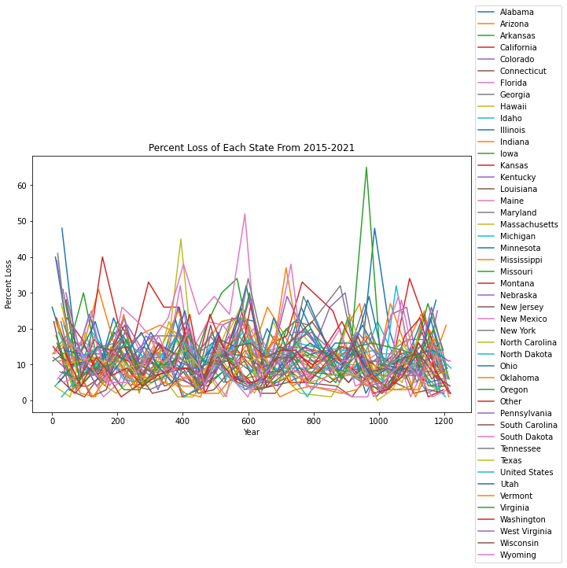

```python
# Makes plot size bigger
figure(figsize=(10, 6))

# Change the Percent Loss column to numerics so it's able to plot
bee_col_loss['Percent Loss'] = pd.to_numeric(bee_col_loss['Percent Loss'], errors = 'coerce')

# Drop NaN rows
bee_col_loss = bee_col_loss.dropna()

# Plot out each states' percent loss from 2015-2021
bee_col_loss.groupby('State')['Percent Loss'].plot(legend = True)
plt.ylabel("Percent Loss")
plt.xlabel("Year")
plt.title("Percent Loss of Each State From 2015-2021")
plt.legend(loc='center left', bbox_to_anchor=(1.0, 0.5))
```

Seeing the dataset so cluttered, I decided to plot the states' percent loss based on map region. Where:

- West: California, Nevada, Utah, Colorado, Wyoming, Idaho, Montana, Washington, Oregon, Alaska
- Northeast: Massachusetts, Rhode Island, Connecticut, Vermont, New Hampshire, Maine, Pennsylvania, New Jersey, New York
- South: Louisiana, Arkansas, Mississippi, Alabama, Georgia, Florida, South Carolina, North Carolina, Tennessee, Kentucky, Virginia, West Virginia, Maryland, Delaware
- Midwest: North Dakota, South Dakota, Nebraska, Kansas, Missouri, Iowa, Minnesota, Wisconsin, Illinois, Indiana, Michigan, Ohio
- Southwest: Arizona, New Mexico, Texas, Oklahoma

```python
# Drop the 'Other' states in the dataset
bee_col_loss = bee_col_loss[bee_col_loss['State'] != 'Other']
bee_col_loss.head()
```

|  | State | Percent Loss | Date |
| --- | --- | --- | --- |
| 0 | Alabama | 26.0 | 2015-01-01 |
| 1 | Arizona | 13.0 | 2015-01-01 |
| 2 | Arkansas | 11.0 | 2015-01-01 |
| 3 | California | 15.0 | 2015-01-01 |
| 4 | Colorado | 12.0 | 2015-01-01 |

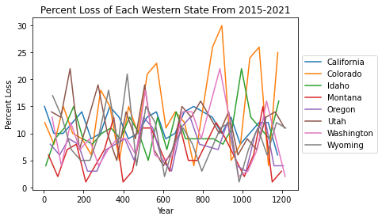

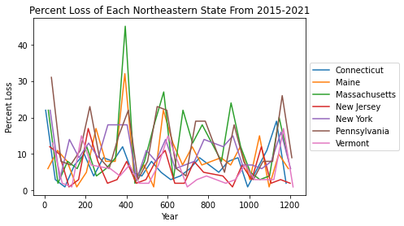

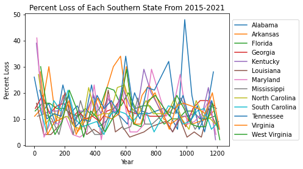

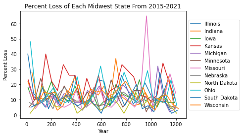

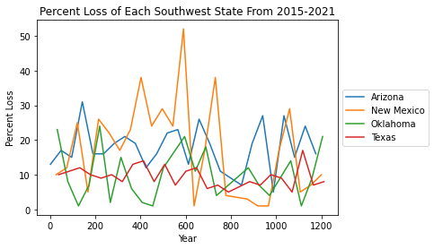

```python
# Creates new datasets with states within a region and U.S. by itself
bee_col_loss_w = bee_col_loss[(bee_col_loss['State'] == 'California') | (bee_col_loss['State'] == 'Nevada') | (bee_col_loss['State'] == 'Utah') | (bee_col_loss['State'] == 'Colorado') | (bee_col_loss['State'] == 'Wyoming') | (bee_col_loss['State'] == 'Idaho') | (bee_col_loss['State'] == 'Montana') | (bee_col_loss['State'] == 'Washington') | (bee_col_loss['State'] == 'Oregon') | (bee_col_loss['State'] == 'Alaska')]
bee_col_loss_ne = bee_col_loss[(bee_col_loss['State'] == 'Massachusetts') | (bee_col_loss['State'] == 'Rhode Island') | (bee_col_loss['State'] == 'Connecticut') | (bee_col_loss['State'] == 'Vermont') | (bee_col_loss['State'] == 'New Hampshire') | (bee_col_loss['State'] == 'Maine') | (bee_col_loss['State'] == 'Pennsylvania') | (bee_col_loss['State'] == 'New Jersey') | (bee_col_loss['State'] == 'New York')]
bee_col_loss_s = bee_col_loss[(bee_col_loss['State'] == 'Louisiana') | (bee_col_loss['State'] == 'Arkansas') | (bee_col_loss['State'] == 'Mississippi') | (bee_col_loss['State'] == 'Alabama') | (bee_col_loss['State'] == 'Georgia') | (bee_col_loss['State'] == 'Florida') | (bee_col_loss['State'] == 'South Carolina') | (bee_col_loss['State'] == 'North Carolina') | (bee_col_loss['State'] == 'Tennessee') | (bee_col_loss['State'] == 'Kentucky') | (bee_col_loss['State'] == 'Virginia') | (bee_col_loss['State'] == 'West Virginia') | (bee_col_loss['State'] == 'Maryland') | (bee_col_loss['State'] == 'Delaware')]
bee_col_loss_mw = bee_col_loss[(bee_col_loss['State'] == 'North Dakota') | (bee_col_loss['State'] == 'South Dakota') | (bee_col_loss['State'] == 'Nebraska') | (bee_col_loss['State'] == 'Kansas') | (bee_col_loss['State'] == 'Missouri') | (bee_col_loss['State'] == 'Iowa') | (bee_col_loss['State'] == 'Minnesota') | (bee_col_loss['State'] == 'Wisconsin') | (bee_col_loss['State'] == 'Illinois') | (bee_col_loss['State'] == 'Indiana') | (bee_col_loss['State'] == 'Michigan') | (bee_col_loss['State'] == 'Ohio')]
bee_col_loss_sw = bee_col_loss[(bee_col_loss['State'] == 'Arizona') | (bee_col_loss['State'] == 'New Mexico') | (bee_col_loss['State'] == 'Texas') | (bee_col_loss['State'] == 'Oklahoma')]

# Check if all region states are in the dataframe
bee_col_loss_w['State'].unique()
bee_col_loss_ne['State'].unique() # Rhode Island not in list, could be Other?
bee_col_loss_s['State'].unique() # No Delaware found in set, could be Other?
bee_col_loss_mw['State'].unique()
bee_col_loss_sw['State'].unique()

# Generate plots for each region
# West
fig,ax = plt.subplots()
bee_col_loss_w.groupby('State')['Percent Loss'].plot(legend = True)
plt.ylabel("Percent Loss")
plt.xlabel("Year")
plt.title("Percent Loss of Each Western State From 2015-2021")
plt.legend(loc='center left', bbox_to_anchor=(1.0, 0.5))

# Northeast
fig,ax = plt.subplots()
bee_col_loss_ne.groupby('State')['Percent Loss'].plot(legend = True)
plt.ylabel("Percent Loss")
plt.xlabel("Year")
plt.title("Percent Loss of Each Northeastern State From 2015-2021")
plt.legend(loc='center left', bbox_to_anchor=(1.0, 0.5))

# South
fig,ax = plt.subplots()
bee_col_loss_s.groupby('State')['Percent Loss'].plot(legend = True)
plt.ylabel("Percent Loss")
plt.xlabel("Year")
plt.title("Percent Loss of Each Southern State From 2015-2021")
plt.legend(loc='center left', bbox_to_anchor=(1.0, 0.5))

# Midwest
fig,ax = plt.subplots()
bee_col_loss_mw.groupby('State')['Percent Loss'].plot(legend = True)
plt.ylabel("Percent Loss")
plt.xlabel("Year")
plt.title("Percent Loss of Each Midwest State From 2015-2021")
plt.legend(loc='center left', bbox_to_anchor=(1.0, 0.5))

# Southwest
fig,ax = plt.subplots()
bee_col_loss_sw.groupby('State')['Percent Loss'].plot(legend = True)
plt.ylabel("Percent Loss")
plt.xlabel("Year")
plt.title("Percent Loss of Each Southwest State From 2015-2021")
plt.legend(loc='center left', bbox_to_anchor=(1.0, 0.5))
```

Some graphs are more readable by splitting into regions, however it may be more helpful to distinguish a general trend of a region by taking the mean of each region's colony percent loss and plotting it.

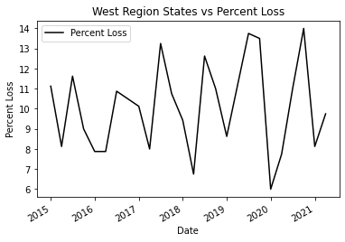

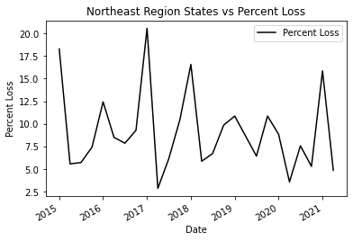

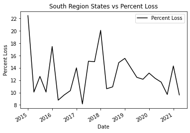

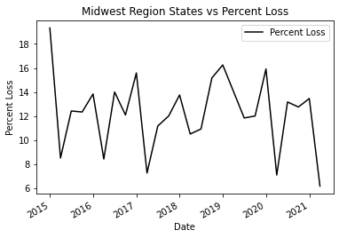

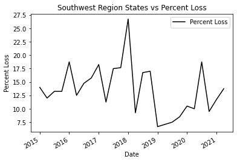

```python
# Generating the average percent loss for each quarter of the year from 2015-2021
# for each regions.
# West
bee_col_loss_w.groupby(['Date']).mean().plot(color="black")
plt.ylabel("Percent Loss")
plt.title("West Region States vs Percent Loss")

# Northeast
bee_col_loss_ne.groupby(['Date']).mean().plot(color="black")
plt.ylabel("Percent Loss")
plt.title("Northeast Region States vs Percent Loss")

# South
bee_col_loss_s.groupby(['Date']).mean().plot(color="black")
plt.ylabel("Percent Loss")
plt.title("South Region States vs Percent Loss")

# Midwest
bee_col_loss_mw.groupby(['Date']).mean().plot(color="black")
plt.ylabel("Percent Loss")
plt.title("Midwest Region States vs Percent Loss")

# Southwest
bee_col_loss_sw.groupby(['Date']).mean().plot(color="black")
plt.ylabel("Percent Loss")
plt.title("Southwest Region States vs Percent Loss")
```

```python
# Getting the averages of the graphed line plots of each region
print("Average percent loss in Western region: " + str(bee_col_loss_w.groupby(['Date']).mean().mean()))
print("Average percent loss in Northeastern region: " + str(bee_col_loss_ne.groupby(['Date']).mean().mean()))
print("Average percent loss in Southern region: " + str(bee_col_loss_s.groupby(['Date']).mean().mean()))
print("Average percent loss in Midwestern region: " + str(bee_col_loss_mw.groupby(['Date']).mean().mean()))
print("Average percent loss in Southwestern region: " + str(bee_col_loss_sw.groupby(['Date']).mean().mean()))
```

```
Average percent loss in Western region: Percent Loss    10.057143
dtype: float64
Average percent loss in Northeastern region: Percent Loss    9.128571
dtype: float64
Average percent loss in Southern region: Percent Loss    12.84
dtype: float64
Average percent loss in Midwestern region: Percent Loss    12.234848
dtype: float64
Average percent loss in Southwestern region: Percent Loss    13.823333
dtype: float64
```

Now that the bee colony data is more readable, taking a look at the means of each region's mean percent loss over the years shows that the Southwest region has the highest average percent loss of bee colonies of 13%. The region with the least average percent loss is the Northeast region at 9%.

Based on the graphs it seems that there's a correlation between the season of the year and average percent loss. To further examine a possible relationship, the data corresponding to the spring and summer months as well as the fall and winter months must be grouped for each region.

One thing to note is that honey bees operate in seasons. Warmer seasons, like spring and summer are when bees fly out and forage, collecting resources such as nectar to feed their brood (baby bees). The majority of the brood then grow into more workers that collect more resources for the colony. During the fall the bees prepare to overwinter, basically waiting out winter, and collect resources as well as kick out the drone bees to prepare for it.

[figure not shown]

```python
# Seeing available months to group the data in
bee_col_loss_w.Date.unique()
```

```
array(['2015-01-01T00:00:00.000000000', '2015-04-01T00:00:00.000000000',
       '2015-07-01T00:00:00.000000000', '2015-10-01T00:00:00.000000000',
       '2016-01-01T00:00:00.000000000', '2016-04-01T00:00:00.000000000',
       '2016-07-01T00:00:00.000000000', '2016-10-01T00:00:00.000000000',
       '2017-01-01T00:00:00.000000000', '2017-04-01T00:00:00.000000000',
       '2017-07-01T00:00:00.000000000', '2017-10-01T00:00:00.000000000',
       '2018-01-01T00:00:00.000000000', '2018-04-01T00:00:00.000000000',
       '2018-07-01T00:00:00.000000000', '2018-10-01T00:00:00.000000000',
       '2019-01-01T00:00:00.000000000', '2019-07-01T00:00:00.000000000',
       '2019-10-01T00:00:00.000000000', '2020-01-01T00:00:00.000000000',
       '2020-04-01T00:00:00.000000000', '2020-07-01T00:00:00.000000000',
       '2020-10-01T00:00:00.000000000', '2021-01-01T00:00:00.000000000',
       '2021-04-01T00:00:00.000000000'], dtype='datetime64[ns]')
```

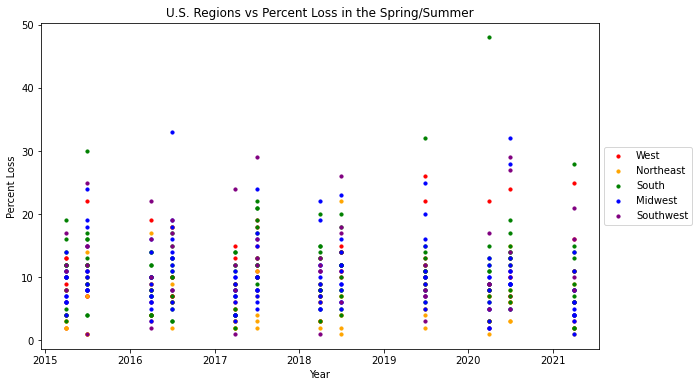

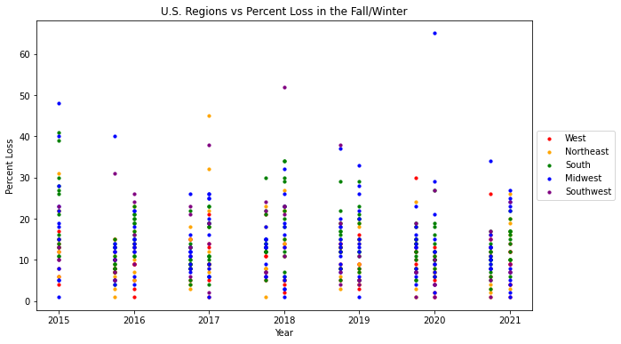

```python
# Creating new datasets with only the spring/summer months and fall/winter months for each region
# West
spr_sum_w = bee_col_loss_w[(bee_col_loss_w.Date.dt.month == 4) | (bee_col_loss_w.Date.dt.month == 7)]
fal_win_w = bee_col_loss_w[(bee_col_loss_w.Date.dt.month == 1) | (bee_col_loss_w.Date.dt.month == 10)]

# Northeast
spr_sum_ne = bee_col_loss_ne[(bee_col_loss_ne.Date.dt.month == 4) | (bee_col_loss_ne.Date.dt.month == 7)]
fal_win_ne = bee_col_loss_ne[(bee_col_loss_ne.Date.dt.month == 1) | (bee_col_loss_ne.Date.dt.month == 10)]

# Southern
spr_sum_s = bee_col_loss_s[(bee_col_loss_s.Date.dt.month == 4) | (bee_col_loss_s.Date.dt.month == 7)]
fal_win_s = bee_col_loss_s[(bee_col_loss_s.Date.dt.month == 1) | (bee_col_loss_s.Date.dt.month == 10)]

# Midwest
spr_sum_mw = bee_col_loss_mw[(bee_col_loss_mw.Date.dt.month == 4) | (bee_col_loss_mw.Date.dt.month == 7)]
fal_win_mw = bee_col_loss_mw[(bee_col_loss_mw.Date.dt.month == 1) | (bee_col_loss_mw.Date.dt.month == 10)]

# Southwest
spr_sum_sw = bee_col_loss_sw[(bee_col_loss_sw.Date.dt.month == 4) | (bee_col_loss_sw.Date.dt.month == 7)]
fal_win_sw = bee_col_loss_sw[(bee_col_loss_sw.Date.dt.month == 1) | (bee_col_loss_sw.Date.dt.month == 10)]

# Creating the scatter plot for the spring/summer months with all the regions
fig = plt.figure(figsize=(10, 6))
ax1 = fig.add_subplot(111)
ax1.scatter(spr_sum_w['Date'], spr_sum_w['Percent Loss'], s=10, c='r', label='West')
ax1.scatter(spr_sum_ne['Date'], spr_sum_ne['Percent Loss'], s=10, c='orange', label='Northeast')
ax1.scatter(spr_sum_s['Date'], spr_sum_s['Percent Loss'], s=10, c='g', label='South')
ax1.scatter(spr_sum_mw['Date'], spr_sum_mw['Percent Loss'], s=10, c='blue', label='Midwest')
ax1.scatter(spr_sum_sw['Date'], spr_sum_sw['Percent Loss'], s=10, c='purple', label='Southwest')
plt.ylabel("Percent Loss")
plt.xlabel("Year")
plt.title("U.S. Regions vs Percent Loss in the Spring/Summer")
plt.legend(loc='center left', bbox_to_anchor=(1.0, 0.5))
plt.show()

# Creating the scatter plot for the fall/winter months with all the regions
fig = plt.figure(figsize=(10, 6))
ax1 = fig.add_subplot(111)
ax1.scatter(fal_win_w['Date'], fal_win_w['Percent Loss'], s=10, c='r', label='West')
ax1.scatter(fal_win_ne['Date'], fal_win_ne['Percent Loss'], s=10, c='orange', label='Northeast')
ax1.scatter(fal_win_s['Date'], fal_win_s['Percent Loss'], s=10, c='g', label='South')
ax1.scatter(fal_win_mw['Date'], fal_win_mw['Percent Loss'], s=10, c='blue', label='Midwest')
ax1.scatter(fal_win_sw['Date'], fal_win_sw['Percent Loss'], s=10, c='purple', label='Southwest')
plt.ylabel("Percent Loss")
plt.xlabel("Year")
plt.title("U.S. Regions vs Percent Loss in the Fall/Winter")
plt.legend(loc='center left', bbox_to_anchor=(1.0, 0.5))
plt.show()
```

Overall it seems that during the fall/winter seasons most of the regions' percent loss ranges pushes upwards towards the 30% - mid-40%. There also exists more outliers that are higher than the typical range. To better get the idea of how seasons may affect each region, we can plot each regions' seasonal data as violin graphs.

```
Western Region Percent Loss:
Average percent loss in spring: Percent Loss    10.114583
dtype: float64
Average percent loss in winter: Percent Loss    10.004121
dtype: float64
```

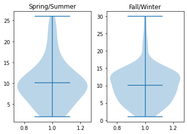

```
Northeastern Region Percent Loss:
Average percent loss in spring: Percent Loss    5.970238
dtype: float64
Average percent loss in winter: Percent Loss    12.043956
dtype: float64
```

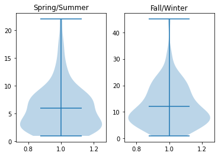

```
Southern Region Percent Loss:
Average percent loss in spring: Percent Loss    10.99359
dtype: float64
Average percent loss in winter: Percent Loss    14.544379
dtype: float64
```

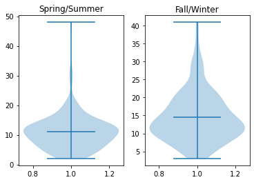

```
Midwestern Region Percent Loss:
Average percent loss in spring: Percent Loss    10.118056
dtype: float64
Average percent loss in winter: Percent Loss    14.188811
dtype: float64
```

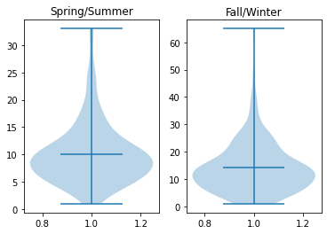

```
Southwestern Region Percent Loss:
Average percent loss in spring: Percent Loss    13.104167
dtype: float64
Average percent loss in winter: Percent Loss    14.487179
dtype: float64
```

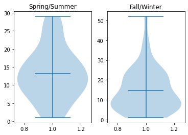

```python
# To create two violin graphs for each region we create a figure that would hold 2 subplots where spring/summer data
# will go into one subplot and fall/winter data will go into the other subplot. Then we ask the violin plot to show
# the mean percent loss for each plot.
# West
print("Western Region Percent Loss:")
print("Average percent loss in spring: " + str(spr_sum_w.groupby(['Date']).mean().mean()))
print("Average percent loss in winter: " + str(fal_win_w.groupby(['Date']).mean().mean()))
fig, (ax1, ax2) = plt.subplots(nrows=1, ncols=2)
ax1.violinplot(spr_sum_w['Percent Loss'], showmeans=True)
ax1.set_title('Spring/Summer')
ax2.violinplot(fal_win_w['Percent Loss'], showmeans=True)
ax2.set_title('Fall/Winter')
plt.show()

# Northeast
print("Northeastern Region Percent Loss:")
print("Average percent loss in spring: " + str(spr_sum_ne.groupby(['Date']).mean().mean()))
print("Average percent loss in winter: " + str(fal_win_ne.groupby(['Date']).mean().mean()))
fig, (ax1, ax2) = plt.subplots(nrows=1, ncols=2)
ax1.violinplot(spr_sum_ne['Percent Loss'], showmeans=True)
ax1.set_title('Spring/Summer')
ax2.violinplot(fal_win_ne['Percent Loss'], showmeans=True)
ax2.set_title('Fall/Winter')
plt.show()

# South
print("Southern Region Percent Loss:")
print("Average percent loss in spring: " + str(spr_sum_s.groupby(['Date']).mean().mean()))
print("Average percent loss in winter: " + str(fal_win_s.groupby(['Date']).mean().mean()))
fig, (ax1, ax2) = plt.subplots(nrows=1, ncols=2)
ax1.violinplot(spr_sum_s['Percent Loss'], showmeans=True)
ax1.set_title('Spring/Summer')
ax2.violinplot(fal_win_s['Percent Loss'], showmeans=True)
ax2.set_title('Fall/Winter')
plt.show()

# Midwest
print("Midwestern Region Percent Loss:")
print("Average percent loss in spring: " + str(spr_sum_mw.groupby(['Date']).mean().mean()))
print("Average percent loss in winter: " + str(fal_win_mw.groupby(['Date']).mean().mean()))
fig, (ax1, ax2) = plt.subplots(nrows=1, ncols=2)
ax1.violinplot(spr_sum_mw['Percent Loss'], showmeans=True)
ax1.set_title('Spring/Summer')
ax2.violinplot(fal_win_mw['Percent Loss'], showmeans=True)
ax2.set_title('Fall/Winter')
plt.show()

# Southwest
print("Southwestern Region Percent Loss:")
print("Average percent loss in spring: " + str(spr_sum_sw.groupby(['Date']).mean().mean()))
print("Average percent loss in winter: " + str(fal_win_sw.groupby(['Date']).mean().mean()))
fig, (ax1, ax2) = plt.subplots(nrows=1, ncols=2)
ax1.violinplot(spr_sum_sw['Percent Loss'], showmeans=True)
ax1.set_title('Spring/Summer')
ax2.violinplot(fal_win_sw['Percent Loss'], showmeans=True)
ax2.set_title('Fall/Winter')
plt.show()
```

On the violin plots the light blue portion plotted shows the distribution of each states' percent losses within a specific region. For the majority of the graphs with the exception of the Southwest spring/summer season, the distributions are right skewed, with more data leaning towards the lower end of the range rather than the higher end. For the Northeast, Midwest, and Southwest regions the range of the fall/winter season distributions almost doubles its range during the spring/summer seasons. Though based on the plotted means, only the Northeast, Midwest, and South regions had a significant jump in their percentage loss from the spring/summer seasons to fall/winter seasons, which could signify a correlation between the season and percentage loss.

# Bee Colony Renovation Data Exploration

Renovation includes requeening a surviving colony, which may help in increasing a colony's brood production, or a large transfer of honey bees into a colony either by nuc or package. A nucleus colony, also known as a split or a nuc, is typically a pre-established hive frame containing a queen, bees, honey, brood, and pollen. While a package only has bees and a queen. Both types are usually installed during the spring and they are helpful in boosting a weak colony's resources in the long run.

A nucleus colony:

[figure not shown]

Package of bees:

[figure not shown]

For this dataset I want to see if there's a correlation between the percent loss and percent renovated other than yearly upkeep.

```python
# Picking out cols to plot the percent loss based on state and date from bee_col dataset
bee_col_ren = bee_col.drop(['Starting Colonies', 'Maximum Colonies', 'Added Colonies', 'Lost Colonies', 'Percent Loss', 'Renovated Colonies', 'Year'], axis = 1)

# Change the Percent Loss column to numerics so it's able to plot
bee_col_ren['Percent Renovated'] = pd.to_numeric(bee_col_ren['Percent Renovated'], errors = 'coerce')

# Drop NaN rows
bee_col_ren = bee_col_ren.dropna()

# Checks what states are within the percent renovated dataset
bee_col_ren.State.unique()
```

```
array(['Alabama', 'Arizona', 'Arkansas', 'California', 'Colorado',
       'Connecticut', 'Florida', 'Georgia', 'Hawaii', 'Idaho', 'Illinois',
       'Indiana', 'Iowa', 'Kansas', 'Kentucky', 'Louisiana', 'Maine',
       'Maryland', 'Massachusetts', 'Michigan', 'Minnesota',
       'Mississippi', 'Missouri', 'Montana', 'Nebraska', 'New Jersey',
       'New Mexico', 'New York', 'North Carolina', 'Ohio', 'Oklahoma',
       'Oregon', 'Pennsylvania', 'South Carolina', 'South Dakota',
       'Tennessee', 'Texas', 'Utah', 'Virginia', 'Washington',
       'West Virginia', 'Wisconsin', 'Wyoming', 'Other', 'United States',
       'North Dakota', 'Vermont'], dtype=object)
```

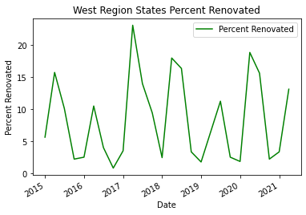

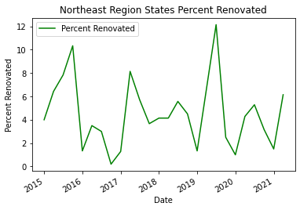

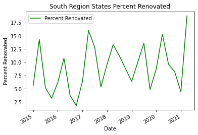

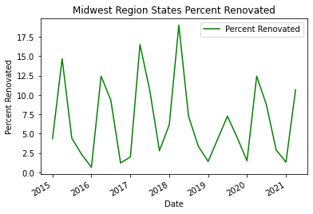

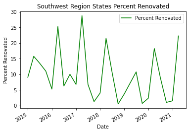

```python
# Creates new datasets with states within a region
ren_w = bee_col_ren[(bee_col_ren['State'] == 'California') | (bee_col_ren['State'] == 'Nevada') | (bee_col_ren['State'] == 'Utah') | (bee_col_ren['State'] == 'Colorado') | (bee_col_ren['State'] == 'Wyoming') | (bee_col_ren['State'] == 'Idaho') | (bee_col_ren['State'] == 'Montana') | (bee_col_ren['State'] == 'Washington') | (bee_col_ren['State'] == 'Oregon') | (bee_col_ren['State'] == 'Alaska')]
ren_ne = bee_col_ren[(bee_col_ren['State'] == 'Massachusetts') | (bee_col_ren['State'] == 'Rhode Island') | (bee_col_ren['State'] == 'Connecticut') | (bee_col_ren['State'] == 'Vermont') | (bee_col_ren['State'] == 'New Hampshire') | (bee_col_ren['State'] == 'Maine') | (bee_col_ren['State'] == 'Pennsylvania') | (bee_col_ren['State'] == 'New Jersey') | (bee_col_ren['State'] == 'New York')]
ren_s = bee_col_ren[(bee_col_ren['State'] == 'Louisiana') | (bee_col_ren['State'] == 'Arkansas') | (bee_col_ren['State'] == 'Mississippi') | (bee_col_ren['State'] == 'Alabama') | (bee_col_ren['State'] == 'Georgia') | (bee_col_ren['State'] == 'Florida') | (bee_col_ren['State'] == 'South Carolina') | (bee_col_ren['State'] == 'North Carolina') | (bee_col_ren['State'] == 'Tennessee') | (bee_col_ren['State'] == 'Kentucky') | (bee_col_ren['State'] == 'Virginia') | (bee_col_ren['State'] == 'West Virginia') | (bee_col_ren['State'] == 'Maryland') | (bee_col_ren['State'] == 'Delaware')]
ren_mw = bee_col_ren[(bee_col_ren['State'] == 'North Dakota') | (bee_col_ren['State'] == 'South Dakota') | (bee_col_ren['State'] == 'Nebraska') | (bee_col_ren['State'] == 'Kansas') | (bee_col_ren['State'] == 'Missouri') | (bee_col_ren['State'] == 'Iowa') | (bee_col_ren['State'] == 'Minnesota') | (bee_col_ren['State'] == 'Wisconsin') | (bee_col_ren['State'] == 'Illinois') | (bee_col_ren['State'] == 'Indiana') | (bee_col_ren['State'] == 'Michigan') | (bee_col_ren['State'] == 'Ohio')]
ren_sw = bee_col_ren[(bee_col_ren['State'] == 'Arizona') | (bee_col_ren['State'] == 'New Mexico') | (bee_col_ren['State'] == 'Texas') | (bee_col_ren['State'] == 'Oklahoma')]

# Generating the average percent loss for each quarter of the year from 2015-2021
# for each regions.
# West
ren_w.groupby(['Date']).mean().plot(color="green")
plt.ylabel("Percent Renovated")
plt.title("West Region States Percent Renovated")

# Northeast
ren_ne.groupby(['Date']).mean().plot(color="green")
plt.ylabel("Percent Renovated")
plt.title("Northeast Region States Percent Renovated")

# South
ren_s.groupby(['Date']).mean().plot(color="green")
plt.ylabel("Percent Renovated")
plt.title("South Region States Percent Renovated")

# Midwest
ren_mw.groupby(['Date']).mean().plot(color="green")
plt.ylabel("Percent Renovated")
plt.title("Midwest Region States Percent Renovated")

# Southwest
ren_sw.groupby(['Date']).mean().plot(color="green")
plt.ylabel("Percent Renovated")
plt.title("Southwest Region States Percent Renovated")
```

```python
# Getting the averages of the graphed line plots of each region
print("Average percent loss in Western region: " + str(ren_w.groupby(['Date']).mean().mean()))
print("Average percent loss in Northeastern region: " + str(ren_ne.groupby(['Date']).mean().mean()))
print("Average percent loss in Southern region: " + str(ren_s.groupby(['Date']).mean().mean()))
print("Average percent loss in Midwestern region: " + str(ren_mw.groupby(['Date']).mean().mean()))
print("Average percent loss in Southwestern region: " + str(ren_sw.groupby(['Date']).mean().mean()))
```

```
Average percent loss in Western region: Percent Renovated    8.487286
dtype: float64
Average percent loss in Northeastern region: Percent Renovated    4.446095
dtype: float64
Average percent loss in Southern region: Percent Renovated    8.957483
dtype: float64
Average percent loss in Midwestern region: Percent Renovated    6.715482
dtype: float64
Average percent loss in Southwestern region: Percent Renovated    9.823333
dtype: float64
```

Out of all the regions, the Southwest region has the highest average of percent renovated of 9.82%. As mentioned in the previous section, the Southwest region also had the highest average percent loss. The Southern region is also the 2nd highest in percent renovated, at 8.96%, similarly to its rank in average percent loss. The lowest average in percent renovated is the Northeastern region, which matches the region's rank in the average percent loss too.

```python
# Check correlation between each regions' percent renovated and percent loss
print("West Regions Percent Renovated vs Percent Loss: " + str(ren_w['Percent Renovated']. corr(bee_col_loss_w['Percent Loss'])))
print("Northeast Regions Percent Renovated vs Percent Loss: " + str(ren_ne['Percent Renovated']. corr(bee_col_loss_ne['Percent Loss'])))
print("South Regions Percent Renovated vs Percent Loss: " + str(ren_s['Percent Renovated']. corr(bee_col_loss_s['Percent Loss'])))
print("Midwest Regions Percent Renovated vs Percent Loss: " + str(ren_mw['Percent Renovated']. corr(bee_col_loss_mw['Percent Loss'])))
print("Southwest Regions Percent Renovated vs Percent Loss: " + str(ren_sw['Percent Renovated']. corr(bee_col_loss_sw['Percent Loss'])))
```

```
West Regions Percent Renovated vs Percent Loss: 0.03090562377166431
Northeast Regions Percent Renovated vs Percent Loss: -0.09597442625889892
South Regions Percent Renovated vs Percent Loss: -0.09805269273274267
Midwest Regions Percent Renovated vs Percent Loss: -0.08983273146566155
Southwest Regions Percent Renovated vs Percent Loss: -0.10174959159453646
```

Based on the correlations there isn't a strong indicator that the percent loss affects the percent renovated.

# Bee Stressor Dataset Exploration

[figure not shown]

Bee infected with varroa mites and deformed wing virus

In addition to their winter survival, imported bee species face a variety of different stressors. Including pesticides, pests such as hive beetles and varroa mites, environmental stress, diseases, and even a phenomenon called colony collapse disorder. This section aims to identify the major stressors for bee colonies from each U.S. region from 2015-2021.

```python
# Calling bee stressor dataset to examine the number of rows and existing columns
cols = bee_stress.columns.drop(['State', 'Date'])
bee_stress[cols] = bee_stress[cols].apply(pd.to_numeric, errors='coerce')

# Checking the types of all the columns
bee_stress.dtypes
```

```
State                                          object
Varroa Mites (Percent)                        float64
Other pests and parasites (Percent)           float64
Diseases (percent)                            float64
Pesticides (percent)                          float64
Other (percent)                               float64
Unknown (percent)                             float64
Year                                          float64
Date                                   datetime64[ns]
dtype: object
```

Want to plot each stressor by region and find the most common cause

```python
# Drop the Year column
bee_stress = bee_stress.drop(['Year'], axis = 1)

# Drop NaN rows
bee_stress = bee_stress.dropna()

# Creates new datasets with states within a region
bee_stress_w = bee_stress[(bee_stress['State'] == 'California') | (bee_stress['State'] == 'Nevada') | (bee_stress['State'] == 'Utah') | (bee_stress['State'] == 'Colorado') | (bee_stress['State'] == 'Wyoming') | (bee_stress['State'] == 'Idaho') | (bee_stress['State'] == 'Montana') | (bee_stress['State'] == 'Washington') | (bee_stress['State'] == 'Oregon') | (bee_stress['State'] == 'Alaska')]
bee_stress_ne = bee_stress[(bee_stress['State'] == 'Massachusetts') | (bee_stress['State'] == 'Rhode Island') | (bee_stress['State'] == 'Connecticut') | (bee_stress['State'] == 'Vermont') | (bee_stress['State'] == 'New Hampshire') | (bee_stress['State'] == 'Maine') | (bee_stress['State'] == 'Pennsylvania') | (bee_stress['State'] == 'New Jersey') | (bee_stress['State'] == 'New York')]
bee_stress_s = bee_stress[(bee_stress['State'] == 'Louisiana') | (bee_stress['State'] == 'Arkansas') | (bee_stress['State'] == 'Mississippi') | (bee_stress['State'] == 'Alabama') | (bee_stress['State'] == 'Georgia') | (bee_stress['State'] == 'Florida') | (bee_stress['State'] == 'South Carolina') | (bee_stress['State'] == 'North Carolina') | (bee_stress['State'] == 'Tennessee') | (bee_stress['State'] == 'Kentucky') | (bee_stress['State'] == 'Virginia') | (bee_stress['State'] == 'West Virginia') | (bee_stress['State'] == 'Maryland') | (bee_stress['State'] == 'Delaware')]
bee_stress_mw = bee_stress[(bee_stress['State'] == 'North Dakota') | (bee_stress['State'] == 'South Dakota') | (bee_stress['State'] == 'Nebraska') | (bee_stress['State'] == 'Kansas') | (bee_stress['State'] == 'Missouri') | (bee_stress['State'] == 'Iowa') | (bee_stress['State'] == 'Minnesota') | (bee_stress['State'] == 'Wisconsin') | (bee_stress['State'] == 'Illinois') | (bee_stress['State'] == 'Indiana') | (bee_stress['State'] == 'Michigan') | (bee_stress['State'] == 'Ohio')]
bee_stress_sw = bee_stress[(bee_stress['State'] == 'Arizona') | (bee_stress['State'] == 'New Mexico') | (bee_stress['State'] == 'Texas') | (bee_stress['State'] == 'Oklahoma')]

# Drop the State column and get the average of each stressor for each quarter of
# the year from 2015-2021
bee_stress_w = bee_stress_w.drop(['State'], axis = 1)
bee_stress_ne = bee_stress_ne.drop(['State'], axis = 1)
bee_stress_s = bee_stress_s.drop(['State'], axis = 1)
bee_stress_mw = bee_stress_mw.drop(['State'], axis = 1)
bee_stress_sw = bee_stress_sw.drop(['State'], axis = 1)

# Examine one of the bee stressor dataset
bee_stress_w
```

|  | Varroa Mites (Percent) | Other pests and parasites (Percent) | Diseases (percent) | Pesticides (percent) | Other (percent) | Unknown (percent) | Date |
| --- | --- | --- | --- | --- | --- | --- | --- |
| 3 | 24.7 | 7.2 | 3.0 | 7.5 | 6.5 | 2.8 | 2015-01-01 |
| 4 | 14.6 | 0.9 | 1.8 | 0.6 | 2.6 | 5.9 | 2015-01-01 |
| 9 | 39.8 | 6.7 | 12.5 | 4.8 | 8.9 | 4.9 | 2015-01-01 |
| 23 | 8.7 | 0.5 | 0.6 | 0.8 | 2.3 | 7.9 | 2015-01-01 |
| 32 | 20.2 | 2.0 | 0.4 | 0.6 | 1.6 | 1.1 | 2015-01-01 |
| ... | ... | ... | ... | ... | ... | ... | ... |
| 1122 | 25.5 | 20.2 | 22.9 | 2.6 | 4.7 | 4.4 | 2020-10-01 |
| 1131 | 29.9 | 5.7 | 1.7 | 7.2 | 6.2 | 3.4 | 2021-01-01 |
| 1132 | 2.1 | 0.0 | 0.0 | 0.0 | 1.1 | 7.8 | 2021-01-01 |
| 1137 | 33.3 | 10.7 | 0.0 | 9.5 | 1.8 | 1.7 | 2021-01-01 |
| 1166 | 45.4 | 0.9 | 0.0 | 2.4 | 1.0 | 11.2 | 2021-01-01 |

154 rows × 7 columns

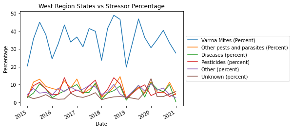

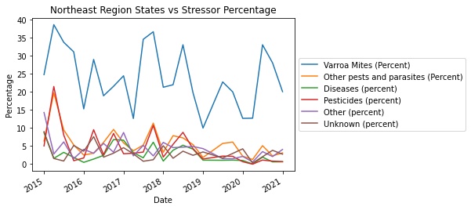

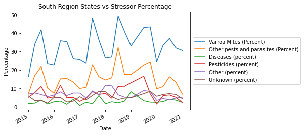

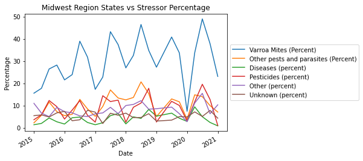

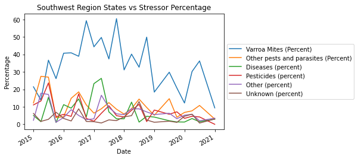

```python
# Averaging each stressors' percentage for each quarter of the year, then
# dropping the NaN rows and plotting the data.
# Western region
stress_w = bee_stress_w.groupby('Date').mean()
stress_w = stress_w.dropna()
stress_w.plot()
plt.ylabel("Percentage")
plt.title("West Region States vs Stressor Percentage")
plt.legend(loc='center left', bbox_to_anchor=(1.0, 0.5))

# Northeastern region
stress_ne = bee_stress_ne.groupby('Date').mean()
stress_ne = stress_ne.dropna()
stress_ne.plot()
plt.ylabel("Percentage")
plt.title("Northeast Region States vs Stressor Percentage")
plt.legend(loc='center left', bbox_to_anchor=(1.0, 0.5))

# Southern region
stress_s = bee_stress_s.groupby('Date').mean()
stress_s = stress_s.dropna()
stress_s.plot()
plt.ylabel("Percentage")
plt.title("South Region States vs Stressor Percentage")
plt.legend(loc='center left', bbox_to_anchor=(1.0, 0.5))

# Midwestern region
stress_mw = bee_stress_mw.groupby('Date').mean()
stress_mw = stress_mw.dropna()
stress_mw.plot()
plt.ylabel("Percentage")
plt.title("Midwest Region States vs Stressor Percentage")
plt.legend(loc='center left', bbox_to_anchor=(1.0, 0.5))

# Southwestern region
stress_sw = bee_stress_sw.groupby('Date').mean()
stress_sw = stress_sw.dropna()
stress_sw.plot()
plt.ylabel("Percentage")
plt.title("Southwest Region States vs Stressor Percentage")
plt.legend(loc='center left', bbox_to_anchor=(1.0, 0.5))
```

```python
# Showing summary statistics of the West region
stress_w.describe()
```

|  | Varroa Mites (Percent) | Other pests and parasites (Percent) | Diseases (percent) | Pesticides (percent) | Other (percent) | Unknown (percent) |
| --- | --- | --- | --- | --- | --- | --- |
| count | 24.000000 | 24.000000 | 24.000000 | 24.000000 | 24.000000 | 24.000000 |
| mean | 35.570615 | 7.986161 | 6.294459 | 7.160655 | 6.566255 | 3.775541 |
| std | 8.243724 | 3.552706 | 3.217615 | 3.463980 | 2.282327 | 2.404781 |
| min | 19.766667 | 2.433333 | 0.425000 | 2.133333 | 2.525000 | 1.500000 |
| 25% | 31.015625 | 5.053571 | 4.306696 | 4.478750 | 4.614286 | 2.401429 |
| 50% | 35.971429 | 7.928750 | 6.172917 | 6.450000 | 6.486905 | 3.216667 |
| 75% | 41.483929 | 11.310000 | 9.303125 | 9.554018 | 8.206250 | 4.447500 |
| max | 48.875000 | 14.466667 | 11.050000 | 13.875000 | 10.500000 | 13.300000 |

```python
# Showing summary statistics of the Northeast region
stress_ne.describe()
```

|  | Varroa Mites (Percent) | Other pests and parasites (Percent) | Diseases (percent) | Pesticides (percent) | Other (percent) | Unknown (percent) |
| --- | --- | --- | --- | --- | --- | --- |
| count | 24.000000 | 24.000000 | 24.000000 | 24.000000 | 24.000000 | 24.000000 |
| mean | 24.071300 | 5.838125 | 2.754425 | 4.491419 | 4.147183 | 3.182153 |
| std | 8.317628 | 3.952251 | 2.378140 | 4.818572 | 2.874247 | 2.076946 |
| min | 10.014286 | 1.300000 | 0.050000 | 0.000000 | 0.600000 | 0.300000 |
| 25% | 19.589286 | 3.106250 | 1.068750 | 1.356429 | 2.251786 | 1.685000 |
| 50% | 22.410000 | 5.368333 | 1.823333 | 2.750000 | 3.777500 | 2.914286 |
| 75% | 31.630000 | 6.617857 | 3.936667 | 6.150000 | 4.975000 | 3.937500 |
| max | 38.683333 | 19.750000 | 8.725000 | 21.533333 | 14.325000 | 9.000000 |

```python
# Showing summary statistics of the South region
stress_s.describe()
```

|  | Varroa Mites (Percent) | Other pests and parasites (Percent) | Diseases (percent) | Pesticides (percent) | Other (percent) | Unknown (percent) |
| --- | --- | --- | --- | --- | --- | --- |
| count | 24.000000 | 24.000000 | 24.000000 | 24.000000 | 24.000000 | 24.000000 |
| mean | 32.828927 | 15.369684 | 2.905118 | 7.123284 | 6.710382 | 5.342181 |
| std | 8.631657 | 6.095614 | 1.613703 | 3.663696 | 2.127496 | 1.824104 |
| min | 16.388889 | 6.885714 | 0.666667 | 1.440000 | 3.460000 | 1.957143 |
| 25% | 25.864583 | 10.512363 | 1.891667 | 4.870455 | 5.166434 | 3.902404 |
| 50% | 33.192208 | 15.310839 | 2.615385 | 6.274107 | 6.481410 | 5.295455 |
| 75% | 37.987260 | 17.601923 | 3.375000 | 8.949615 | 7.689423 | 6.716270 |
| max | 49.308333 | 32.175000 | 8.200000 | 16.607692 | 11.766667 | 8.430769 |

```python
# Showing summary statistics of the Midwest region
stress_mw.describe()
```

|  | Varroa Mites (Percent) | Other pests and parasites (Percent) | Diseases (percent) | Pesticides (percent) | Other (percent) | Unknown (percent) |
| --- | --- | --- | --- | --- | --- | --- |
| count | 24.000000 | 24.000000 | 24.000000 | 24.000000 | 24.000000 | 24.000000 |
| mean | 29.928499 | 10.282497 | 3.992250 | 8.997736 | 8.189122 | 5.393951 |
| std | 10.306009 | 4.673366 | 2.242613 | 5.073732 | 2.806015 | 1.615020 |
| min | 7.433333 | 2.250000 | 0.900000 | 1.100000 | 2.766667 | 1.941667 |
| 25% | 23.029167 | 5.981818 | 2.225000 | 3.870000 | 6.356250 | 4.535000 |
| 50% | 29.991364 | 10.795833 | 4.287500 | 9.799167 | 7.825833 | 5.299286 |
| 75% | 37.493750 | 13.469886 | 5.065909 | 12.245833 | 10.105455 | 6.639318 |
| max | 48.942857 | 20.666667 | 9.444444 | 19.585714 | 15.500000 | 7.900000 |

```python
# Showing summary statistics of the Southwest region
stress_sw.describe()
```

|  | Varroa Mites (Percent) | Other pests and parasites (Percent) | Diseases (percent) | Pesticides (percent) | Other (percent) | Unknown (percent) |
| --- | --- | --- | --- | --- | --- | --- |
| count | 23.000000 | 23.000000 | 23.000000 | 23.000000 | 23.000000 | 23.000000 |
| mean | 33.988043 | 10.734058 | 6.970290 | 7.200725 | 6.760507 | 3.613406 |
| std | 13.982420 | 6.619309 | 7.158585 | 5.453191 | 4.728343 | 2.978876 |
| min | 9.400000 | 3.000000 | 1.025000 | 0.000000 | 1.150000 | 0.700000 |
| 25% | 23.837500 | 6.112500 | 1.762500 | 4.212500 | 3.350000 | 1.641667 |
| 50% | 36.300000 | 8.975000 | 4.133333 | 5.700000 | 5.566667 | 2.525000 |
| 75% | 40.841667 | 13.437500 | 10.258333 | 9.395833 | 8.625000 | 4.775000 |
| max | 60.533333 | 27.500000 | 26.325000 | 23.700000 | 17.800000 | 13.025000 |